# Analyzing the Potential Relationship between the Presence of Starbucks and the Gentrification of an Area

Nikhila Iyer

December 01, 2021

# Background + Problem Statement

## Background

### Starbucks

Starbucks is a multinational coffeehouse chain headquartered in Seattle, Washington. Culturally, Starbucks has become a staple within society, but a cup of coffee at Starbucks is not affordable for everyone.

### Gentrification

Gentrification is when more affluent residents and businesses move into a low socioeconomic area.

Leads to:

- increase in property values of the area
- increase in median household income
- increase in percent of residents with a college degree
- population migration and displacement

## Problem Statement

Is there a relationship between number of Starbucks stores in an area and the level of gentrification?

# Initial Approach

## Focuses

- Starbucks location data
- Measurements of gentrification

# Methods + Tools

## Tools to Date

- Pandas
- missingno
- ggplot
- Geo Pandas
- matplotlib/Seaborn
- Naive Bayes

# Preliminary Results

## Starbucks Locations by State

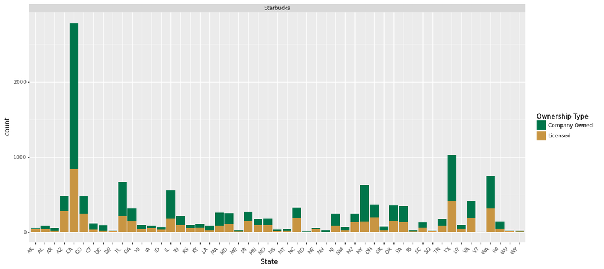

```python
state_breakdown
```

## United States Heat Map of Starbucks Locations

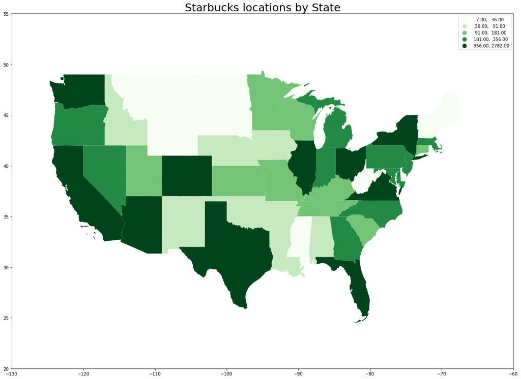

```python
# plot heat map of Starbucks locations
geo_merge.plot(column='Store Name', scheme="quantiles",figsize=(25, 15),legend=True,cmap='Greens')
plt.xlim(-130, -60)
plt.ylim(20, 55)
plt.title('Starbucks locations by State',fontsize=25)
plt.show()
```

## Average Home Price versus Number of Starbucks Locations

### (per State, 2017)

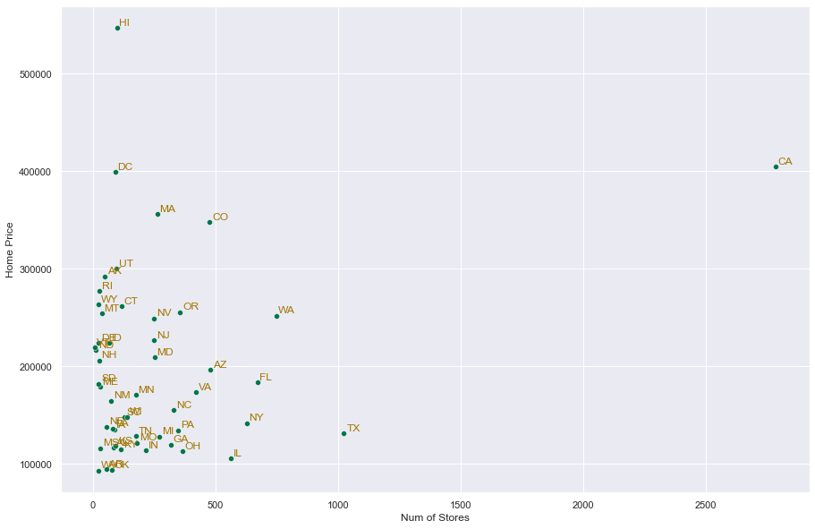

```python
plt.figure(figsize=(15, 10))
sns.scatterplot(data=stores_home_merge, x="Num of Stores", y="Home Price", color="#00754a")
for r in range(stores_home_merge['State'].count()):
    plt.text(x = (stores_home_merge.iloc[r]['Num of Stores'] + 10), y = (stores_home_merge.iloc[r]['Home Price'] + 2500), s = stores_home_merge.iloc[r]['State'], c = "#a17700", size = 12)
```

# Next Steps

## Lessons Learned

- Census data is so much more detailed than expected!
- Better to check for yes/no prediction than vaguely expecting a relationship
- Rabbitholes with data analysis

## Data Considerations

1. Incorporating other measurements, such as population density and race
2. Tweaking the predictive model (Naive Bayes), using additional ones to compare